# Sequence aligmnet of folk songs melodies reveals cross-cultural mechanisms of musical evolution

Sam Passmore

25/06/2021

## Introduction

##### Authors

*Patrick E. Savage, Gakuto Chiba, Thomas E. Currie, Haruo Suzuki, Sam Passmore, and Quentin D. Atkinson*

This document contains the modeling procedure for Savage et al. (2021). [The Pre-print is available here.](https://psyarxiv.com/5rj6y/)

Modeling was performed in response to the reviewers comments after submission to *Current Biology*, which can be summarized into the following bullet points:

- The three hypotheses presented in this paper could be tested in a single model
- There are 66 possible note substitutions (ignoring directionality): the rate of substitutions could be modeled using an independent variable representing the three hypotheses
- These hypotheses relate substitution counts to:
  - Substitution distance (smaller the distance the more likely the substitution)
  - Note count (rarer notes are more likely to change)
  - and location of substitution. (functional notes are less likely to change)

After much thought, we determine that these hypotheses cannot be determined by a single model and need to be split into two categories: hypotheses concerned with mutations (i.e. pairs of notes), and hypotheses concerned with individual notes. However, we can test some hypotheses this way. This document covers hypotheses concerned with substitutions (figure 3 of main text).

The hypotheses we test here are:

- More frequent notes change more often on an absolute basis
- Substitutions with smaller semi-tonal distance are more likely to change
- Substitutions between functional notes should be less common that substitutions between ornamental notes.

## Analysis

### Null model

A null substitution model would suggest that: in the event of a substitution, every note is equally likely to be substituted. Under this model, we would expect the product of the note frequencies would be proportional to the rate of substitutions.

If we find substitutions occuring above this line, this implies they occur more frequently than we would expect, and below this line, less frequently. The second and third hypotheses are then looking to explain the residual variation from this relationship.

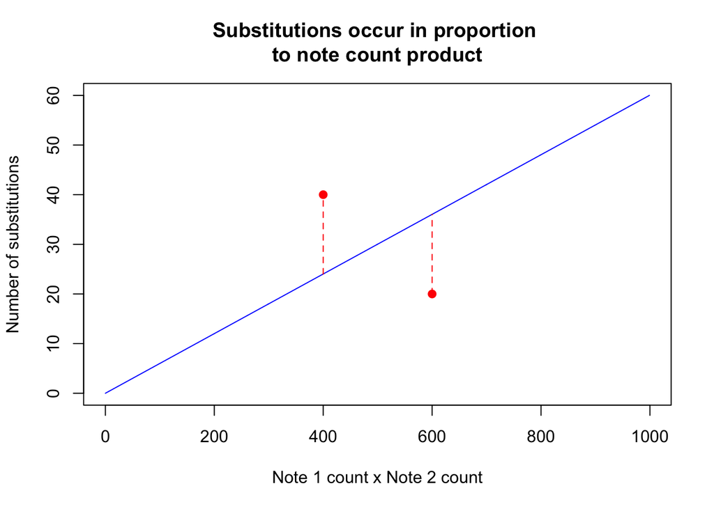

### Observed data

First, we visualize the relationship using the raw data. The number of substitutions is shown on the y-axis and the product of note frequencies on the x-axis. The blue line shows the expected relationship given the null model of random substitutions. Notably, there is considerable variation above and below the line.

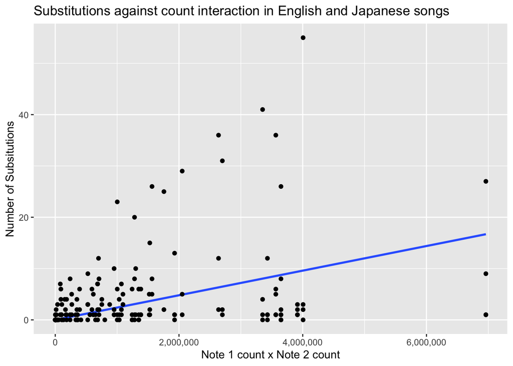

To build a statistical null model, we take the ratio of substitutions to total notes per society using a binomial response, in order to control for the different number of notes and songs in each sample. We then build a model with an origin intercept, since we know that if two notes don’t occur, we cannot have any substitutions. The response is predicted by the product of note counts, excluding main effects. This model is a reasonable fit, however, we want to understand the deviations from this null model.

```r
fit.1 <-
  brm(data = melodic_df, family = binomial,
      mutation_count | trials(total_notes) ~ 0 + std_count1:std_count2,
      prior(normal(0, 1), coef = "std_count1:std_count2"),
      seed = 10, iter = 6000, warmup = 3000, chains = 2, cores = 2,
      control = list(max_treedepth = 15), sample_prior = TRUE,
      save_pars = save_pars(all = TRUE),
      file = "results/null_bin")

summary(fit.1)
```

```
##  Family: binomial
##   Links: mu = logit
## Formula: mutation_count | trials(total_notes) ~ 0 + std_count1:std_count2
##    Data: melodic_df (Number of observations: 215)
## Samples: 2 chains, each with iter = 6000; warmup = 3000; thin = 1;
##          total post-warmup samples = 6000
##
## Population-Level Effects:
##                       Estimate Est.Error l-95% CI u-95% CI Rhat Bulk_ESS
## std_count1:std_count2  -146.58      0.49  -147.53  -145.60 1.00     2035
##                       Tail_ESS
## std_count1:std_count2     3163
##
## Samples were drawn using sampling(NUTS). For each parameter, Bulk_ESS
## and Tail_ESS are effective sample size measures, and Rhat is the potential
## scale reduction factor on split chains (at convergence, Rhat = 1).
```

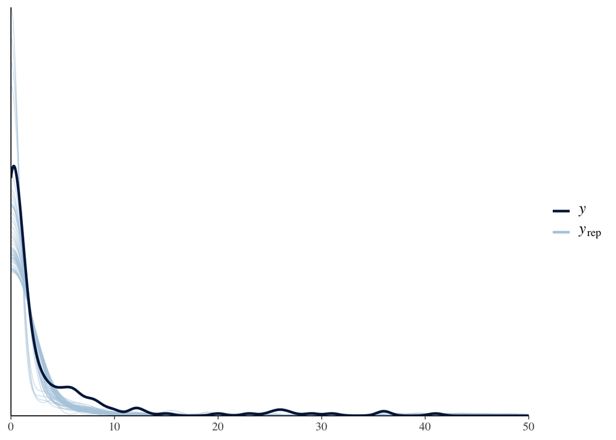

```r
pp_check(fit.1, nsamples = 50) + xlim(c(0 , 50))
```

## Society

A hypothesis not suggested by the reviewer, but we can test here is whether there is a difference between societies in their rate of substitution. We do this by allowing the null slope coefficient to vary by society. A steeper coefficient implies that a society substitutes notes at a higher rate than we would expect under the null model. We can visualize this by plotting the English and Japanese data on separate graphs. Note each graph has its own scales to make the data easier to visualize.

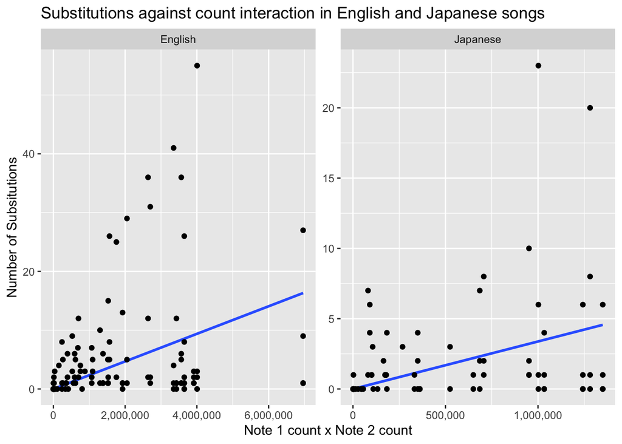

```r
fit.2 <-
  brm(data = melodic_df, family = binomial,
      mutation_count | trials(total_notes) ~
        0 + std_count1:std_count2:society,
      prior(normal(0, 1), class = b),
      seed = 10, iter = 6000, warmup = 3000, chains = 2, cores = 2,
      control = list(max_treedepth = 15), sample_prior = TRUE,
      save_pars = save_pars(all = TRUE),
      file = "results/societyrslopes_bin")

summary(fit.2)
```

```
##  Family: binomial
##   Links: mu = logit
## Formula: mutation_count | trials(total_notes) ~ 0 + std_count1:std_count2:society
##    Data: melodic_df (Number of observations: 215)
## Samples: 2 chains, each with iter = 6000; warmup = 3000; thin = 1;
##          total post-warmup samples = 6000
##
## Population-Level Effects:
##                                       Estimate Est.Error l-95% CI u-95% CI Rhat
## std_count1:std_count2:societyEnglish   -102.02      0.44  -102.90  -101.17 1.00
## std_count1:std_count2:societyJapanese  -147.61      0.61  -148.80  -146.46 1.00
##                                       Bulk_ESS Tail_ESS
## std_count1:std_count2:societyEnglish      5163     4028
## std_count1:std_count2:societyJapanese     5215     4162
##
## Samples were drawn using sampling(NUTS). For each parameter, Bulk_ESS
## and Tail_ESS are effective sample size measures, and Rhat is the potential
## scale reduction factor on split chains (at convergence, Rhat = 1).
```

## Semitonal distance

The first hypothesis we test is whether semi-tonal distance can explain why some note substitutions occur more or less often than expected under the null model. The prediction is that substitutions across smaller semi-tonal distances are likely to occur more often than larger semi-tonal distances. To visualize this relationships, we size the points by their semi-tonal distance shows us that smaller semi-tonal distances occur more often than we would expect under the null model, and larger semi-tonal distances occur less often than we would expect, aligning with the hypothesis. In the graph below, smaller circles indicate smaller semi-tonal distances.

To model this relationship, we extend the previous model by including a semitonal distance predictor as an independent variable.

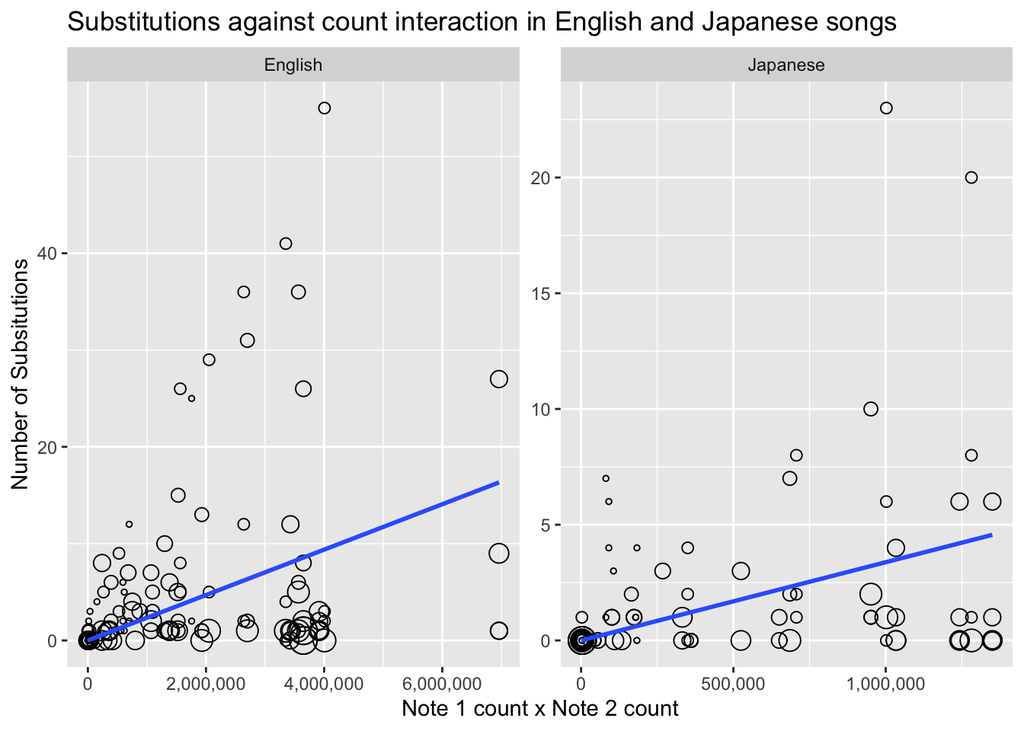

```r
fit.3 <-
  brm(data = melodic_df, family = binomial,
      mutation_count | trials(total_notes) ~
        0 + std_count1:std_count2:society + std_semitonaldistance,
      prior(normal(0, 5), class = b),
      seed = 10, iter = 6000, warmup = 3000, chains = 2, cores = 2,
      control = list(max_treedepth = 15), sample_prior = TRUE,
      save_pars = save_pars(all = TRUE),
      file = "results/semitones_bin")

summary(fit.3)
```

```
##  Family: binomial
##   Links: mu = logit
## Formula: mutation_count | trials(total_notes) ~ 0 + std_count1:std_count2:society + std_semitonaldistance
##    Data: melodic_df (Number of observations: 215)
## Samples: 2 chains, each with iter = 6000; warmup = 3000; thin = 1;
##          total post-warmup samples = 6000
##
## Population-Level Effects:
##                                       Estimate Est.Error l-95% CI u-95% CI Rhat
## std_semitonaldistance                   -87.95      0.52   -88.98   -86.92 1.00
## std_count1:std_count2:societyEnglish      7.03      0.20     6.64     7.42 1.00
## std_count1:std_count2:societyJapanese    27.38      0.85    25.68    29.01 1.00
##                                       Bulk_ESS Tail_ESS
## std_semitonaldistance                     2368     3109
## std_count1:std_count2:societyEnglish      2504     2912
## std_count1:std_count2:societyJapanese     2729     3604
##
## Samples were drawn using sampling(NUTS). For each parameter, Bulk_ESS
## and Tail_ESS are effective sample size measures, and Rhat is the potential
## scale reduction factor on split chains (at convergence, Rhat = 1).
```